# Selection of Travis CI Study Object from GitHub projects

This R notebook documents how we selected projects for our investigation.

## Getting input from GHTorrent (for all languages)

We started off by obtaining a list of projects from [GHTorrent](http://ghtorrent.org/relational.html). We used establish filtering criteria (non-fork, non-deleted repositories with at least 50 stars), detailed in the query (nb. that watchers == stars in GHTorrent, see http://ghtorrent.org/relational.html):

```sql
select u.login, p.name, p.language, count(*)
from projects p, users u, watchers w
where
    p.forked_from is null and
    p.deleted is false and
    w.repo_id = p.id and
    u.id = p.owner_id
group by p.id
having count(*) > 50
order by count(*) desc
into outfile 'ghtorrent_all_projects_100_stars.csv'
  FIELDS TERMINATED BY ',' OPTIONALLY ENCLOSED BY '"'
  LINES TERMINATED BY '\n';
```

We ran this query on GHTorrent on Monday, 19th December 2016. It resulted in a set of 99212 projects.

Here is an overview of the number of stars per project:

```r
projects <- read.csv("ghtorrent_all_projects_51_stars.csv", header = F)
colnames(projects) <-  c('login','project','language','stars')
summary(projects$stars)
```

```
   Min. 1st Qu.  Median    Mean 3rd Qu.    Max.
   51.0    73.0   119.0   342.8   253.0 65940.0
```

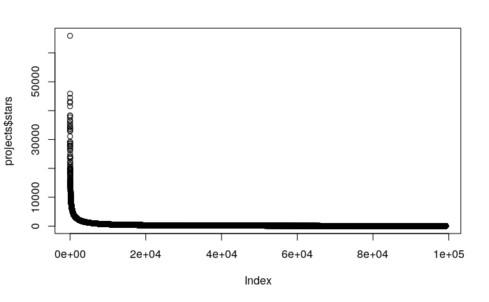

```r
plot(projects$stars)
```

## Selecting Projects in Languages Worth Supporting

```r
summary(projects)
```

```
          login            project             language         stars
 google      :  308   dotfiles :  118   JavaScript :22725   Min.   :   51.0
 sindresorhus:  206   blog     :   62   Python     : 9170   1st Qu.:   73.0
 apache      :  193   core     :   47   Java       : 9161   Median :  119.0
 substack    :  167   docs     :   44   \\N        : 7428   Mean   :  342.8
 facebook    :  161   framework:   26   Objective-C: 6272   3rd Qu.:  253.0
 Microsoft   :  156   examples :   23   Ruby       : 5793   Max.   :65935.0
 (Other)     :98021   (Other)  :98892   (Other)    :38663
```

```r
filtered.projects <- read.csv("java_ruby_python_go_projects_51_stars.csv-annotated.csv", header = F)
colnames(filtered.projects) <-  c('login','project','language','stars','ci_builds')
summary(filtered.projects$ci_builds)
```

```
   Min. 1st Qu.  Median    Mean 3rd Qu.    Max.
    0.0     0.0     0.0   185.2    55.0 56230.0
```

In total, we find that 0.3553044 of projects use Travis CI, i.e. have at least one build on it.

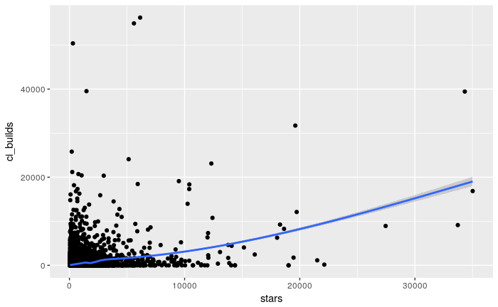

```r
ggplot(filtered.projects, aes(stars, ci_builds)) + geom_point() + geom_smooth()
```

The plot above suggests a relationship between the number of stars in a project and the number of CI builds:

```r
cor.test(filtered.projects$stars, filtered.projects$ci_builds)
```

```
    Pearson's product-moment correlation

data:  filtered.projects$stars and filtered.projects$ci_builds
t = 56.007, df = 27428, p-value < 2.2e-16
alternative hypothesis: true correlation is not equal to 0
95 percent confidence interval:
 0.3096955 0.3309352
sample estimates:
      cor
0.3203556
```

Naturally, while there are of course projects with fewer stars that have many CI builds, we can recognize a moderate trend that as projects have more stars, they also have more CI builds. Reasons might include more committers, thus more commits and more builds, and more established project development guidelines.

Let us focus on only the projects with Travis CI builds:

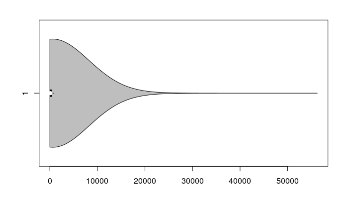

```r
projects.with.builds <- filtered.projects[filtered.projects$ci_builds > 0,]
num.ci_builds <- projects.with.builds[order(projects.with.builds$ci_builds),]$ci_builds
vioplot(num.ci_builds,  horizontal=TRUE, col="gray")
```

In total, we have 5080727 Travis CI builds.

The number of builds is diverging per language. In order to be able to compare between languages, we should analyze the same amount of builds.

```r
summary(projects.with.builds$language)
```

```
    Go   Java Python   Ruby
  1391   2321   3103   2931
```

Moreover, there are too many projects to analyze them all. Hence, we must select a representative sub-sample.

```r
aggregate(ci_builds ~ language, projects.with.builds, sum)
```

| language | ci_builds |
| --- | --- |
| Go | 658231 |
| Java | 1158267 |
| Python | 1829442 |
| Ruby | 1434787 |

To do this, we apply random-stratified sampling such that we get an equal number of comparable projects for each language, and a number that we can computationally and storage-wise handle. Since our data (stars, ci_builds) is of continuous nature, we must map numbers to categories. We use k-means sampling to identify the number of categories.

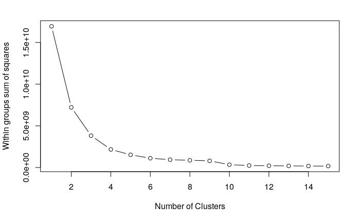

```r
mydata <- data.frame(projects.with.builds$stars)
wss <- (nrow(mydata)-1)*sum(apply(mydata,2,var))
  for (i in 2:15) wss[i] <- sum(kmeans(mydata,
                                       centers=i, iter.max = 15)$withinss)
plot(1:15, wss, type="b", xlab="Number of Clusters",
     ylab="Within groups sum of squares")
```

Using the elbow method, we should cluster stars into 10 clusters.

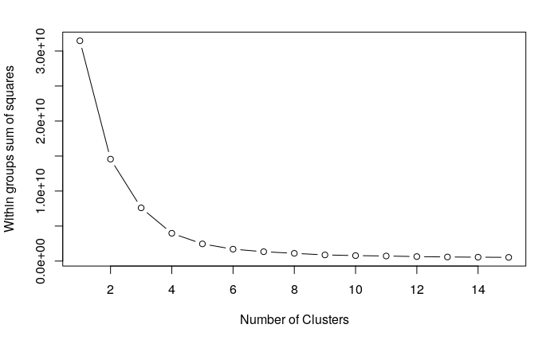

```r
mydata <- data.frame(projects.with.builds$ci_builds)
wss <- (nrow(mydata)-1)*sum(apply(mydata,2,var))
  for (i in 2:15) wss[i] <- sum(kmeans(mydata,
                                       centers=i, iter.max = 15)$withinss)
plot(1:15, wss, type="b", xlab="Number of Clusters",
     ylab="Within groups sum of squares")
```

Using the elbow method, we should cluster ci_builds into 8 clusters.

```r
clustered <- projects.with.builds
clustered$cluster.ci_builds <- kmeans(clustered$ci_builds, centers=8)$cluster
clustered$cluster.stars <- kmeans(clustered$stars, centers=10)$cluster
```

Finally, we can perform stratified random sampling on the newly generated clusters:

```r
stratified.projects <- stratified(clustered, c("language", "cluster.ci_builds", "cluster.stars"), 10)
```

```
Some groups
---Java.7.2, Ruby.2.2, Go.1.2, Ruby.1.2, Python.4.9, Python.5.9, Python.1.9, Ruby.7.9, Python.3.9, Ruby.8.9, Go.8.9, Ruby.3.9, Java.6.9, Python.6.1, Java.5.1, Go.3.1, Go.6.1, Java.6.1, Go.4.1, Ruby.1.1, Python.7.1, Java.3.1, Python.3.1, Java.8.1, Ruby.8.1, Java.4.1, Python.5.1, Ruby.7.1, Go.7.1, Pyt…
contain fewer observations than desired number of samples.
All observations have been returned from those groups.
```

```r
stratified.projects <- unique(stratified.projects)
```

We convince ourselves that the generated sample is more evenly distributed by comparing it to what our starting sample looked like:

```r
summary(stratified.projects$language)
```

```
    Go   Java Python   Ruby
   198    257    269    254
```

## Building a list of projects

This leaves us with 978 projects to analyze. Last, we need to build a list of projects of which the build files should be downloaded:

```r
stratified.projects$ghname <- paste(sep = "@", stratified.projects$login, stratified.projects$project)
write(stratified.projects$ghname, "stratified_project_list_22_12_2016.txt")
```